# Comunicar con RStudio

## Bloques nativos typst

Se puede cambiar la apariencia de bloques mediante llamadas nativas de **Typst**, utilizando la clase `.block` en un **Div** con los argumentos apropiados.

```markdown
::: {.block fill="luma(230)" inset="8pt" radius="4pt"}

Este es un bloque con fondo gris y las aristas redondeadas.

:::
```

## Fórmulas typst

Typst tiene composición tipográfica matemática incorporada y utiliza su propia notación.

La notación va encerrada entre signos $, de forma similar al LaTeX.

```markdown
{=typst}
$ 7.32 beta +
  sum_(i=0)^nabla
    (Q_i (a_i - epsilon)) / 2 $
```

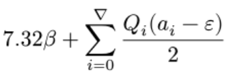

## Word (docx)

[figure not shown]

Las cabecera básica de documentos Word es:

```
---
title: "Mi Documento"
format:
  docx:
    toc: true
    toc-depth: 2
    toc-title: Contenidos
---
```

* en el ejemplo, además activamos tabla de contenidos, con una profundidad de 2 y título de tabla “Contenidos” (en español).

La mayoría de las opciones de ejecución vistas para HTML sirven para este tipo de documentos.

## Plantillas Word

Para personalizar la apariencia de los documentos resultantes en Word se puede añadir en la cabecera una plantilla con diseño modificado. Para esto se sigue el siguiente paso a paso:

1. Desde Word se crea un nuevo documento y se modifica el estilo del documento (tipo de hoja, orientación, márgenes, fuentes, colores, etc)
2. Se almacena el archivo .docx resultante en la carpeta del proyecto RStudio donde estamos construyendo el documento Quarto.
3. En la cabecera YAML del documento Quarto se incluye la línea `reference-doc:` con el nombre del documento anterior (ejemplo: *plantilla.docx*)
4. Al renderizar Quarto toma las características de apariencia definidas y las reproduce en la salida del documento generado.

## Tableros de Quarto®

Los dashboards o tableros de Quarto son archivos **HTML** que pueden ser:

- **Estáticos** Se representan una sola vez y los datos no cambian - pueden incluir elementos dinámicos.
- **Programados** Se representan a partir de un cronograma donde los datos se actualizan
- **Parametrizados** Se modifican a partir de parámetros
- **Interactivo** Mediante Shiny - requieren de servidor especial

## Cabecera YAML

El formato de la cabecera YAML de los tableros de Quarto es `dashboard`.

```yaml
---
title: "Mi tablero"
format: dashboard
---
```

La salida generada es HTML y la estructura se asemeja al uso del paquete flexdashboard de RMarkdown.

Se puede definir como será la orientación y si se habilita el `scrolling` de la página.

Otras opciones específicas de la cabecera YAML para tableros son los logotipos y los botones de navegación.

## Cabecera YAML

Se reconocen alias para botones especiales predeterminados: `linkedin`, `facebook`, `reddit`, `twitter` y `github`. También se pueden crear botones personalizados a partir de [íconos bootstrap](https://icons.getbootstrap.com/).

[figure not shown]

```yaml
    logo: images/INE.gif
    nav-buttons:
      - linkedin
      - twitter
      - github
      - facebook
      - reddit
      - icon: hospital
        href: https://www.ine.gov.ar
        target: _blank
```

## Componentes

Los tableros constan de varios componentes:

**Barra de navegación**: ícono, título y autor junto con enlaces a subpáginas (si se define más de una página).

**Páginas, filas, columnas y conjuntos de pestañas**: las páginas, filas y columnas se definen mediante encabezados de Markdown (con atributos opcionales para controlar la altura, el ancho, etc.). Los conjuntos de pestañas se pueden utilizar para dividir aún más el contenido dentro de una fila o columna.

**Tarjetas, barras laterales y barras de herramientas**: las tarjetas son contenedores para gráficos, visualización de datos y contenido de formato libre. El contenido de las tarjetas generalmente se asigna a celdas en el documento fuente. Las barras laterales y las barras de herramientas se utilizan para presentar entradas dentro de tableros interactivos.

## Diseño

Los elementos de diseño básico son `paginas`, `filas`, `columnas` y `pestañas`.

Las `paginas` se definen con encabezados tamaño 1 (#)

Las filas y columnas se declaran con encabezados tamaño 2 (##)

Las pestañas utilizan la clase `{.tabset}` en filas tipo ## y cada pestaña se declara con un encabezado de tamaño 3 (###)

## Páginas

```yaml
# Pagina 1

# Pagina 2

# Pagina 3
```

[figure not shown]

## Filas

```yaml
## Row {height=30%}

::: {.card title="Fila 30%"}
:::

## Row {height=70%}

::: {.card title="Fila 70%"}
:::
```

[figure not shown]

## Columnas

```yaml
## Column {width=30%}

::: {.card title="Columna 30%"}
:::

## Column {width=70%}

::: {.card title="Columna 70%"}
:::
```

[figure not shown]

## Pestañas

```yaml
## Row {.tabset}

### Pestaña 1

::: {.card title=""}
:::

### Pestaña 2

::: {.card title=""}
:::
```

[figure not shown]

## Barra lateral

````yaml
## {.sidebar}

```{r}
cat("Barra lateral")

cat("Input 1")

cat("Input 2")

cat("Input 3")
```
````

[figure not shown]

## Tarjetas

Las tarjetas que se ubican en las celdas que generan las filas, las columnas y/o las pestañas tienen un botón de expansión automático que maximiza la visualización.

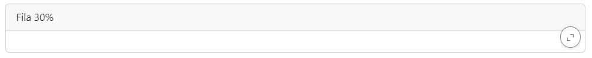

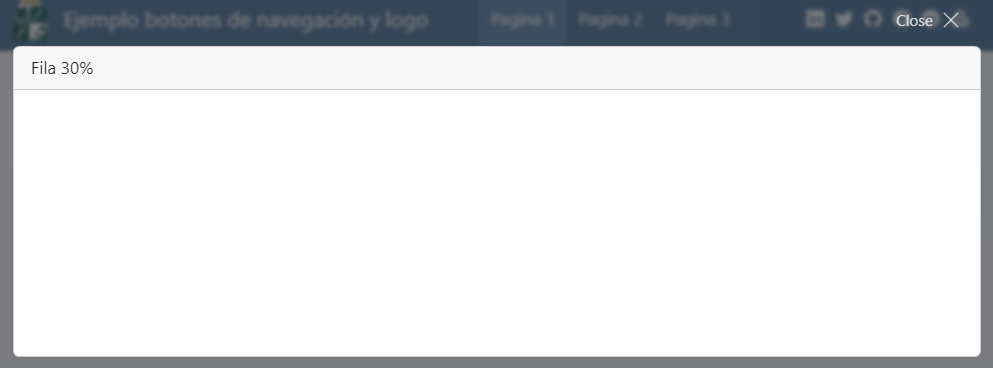